# 多元数据数学表达及R的使用

shixiangzhou

2015年10月5日

# 如何收集和整理多元统计分析资料

## 数据格式

对每一观察单位测量了多个指标(变量)时，一般用矩阵形式表示。

$$X=\begin{pmatrix} x_{11} & x_{12} & \cdots & x_{1p}\\
x_{21} & x_{22} & \cdots & x_{2p}\\
\cdots & \cdots & \cdots & \cdots\\
x_{n1} & x_{n2} & \cdots & x_{np} \end{pmatrix}$$

$$=(x_1,x_2,\cdots,x_p)$$

1. 当这些变量处于同等地位时，就是相关分析，聚类分析，主成分分析，因子分析，对应分析，多维标度等模型的数据格式。
2. 当其中一个变量为因变量时，而其他变量为自变量时，为线性回归分析，广义线性回归模型和非线性模型等。
3. 若此时因变量还是分类变量，则为方差分析模型和判别分析模型。

## 对数据的要求

```
每个观察单位的每个变量都须有数据，不能空缺。
```

## 变量的分类

定量变量—计量观测数据，有单位，身高，体重，收入…

定性变量—计数观测数据，按属性，类别分组，性别，职业等

定性变量一般要先数量化后才能进行多元统计运算

# 数据的数学表达

记得啊，多元数据：$X=(x_1,x_2,\cdots,x_p)$是n*p随机向量。

1. X的期望：$E(x)=(E(x_1),\cdots, E(x_n))$
2. 向量X的协方差矩阵:

$$\sigma=var(X)=\begin{pmatrix} cov(x_1,x_1) & cov(x_1,x_2) & \cdots & cov(x_1,x_p)\\
cov(x_2,x_1) & cov(x_2,x_2) & \cdots & cov(x_2,x_p)\\
\cdots & \cdots & \cdots & \cdots\\
cov(x_p,x_1) & cov(x_p,x_2) & \cdots & cov(x_p,x_p) \end{pmatrix}$$

3. 统计计算：样本均值，协方差矩阵

   太费时间了，我就不写了，去找统计学的教科书吧。

**例题1** 12名学生的生长发育指标，身高$x_1$,体重$x_2$,用R表示

```r
x1=c(171,175,159,155,152,158,154,164,168,166,159,164)#创建一个向量
x2=c(57,64,41,38,35,44,41,51,57,49,47,46)
length(x1)#向量的长度
```

```
## [1] 12
```

```r
mode(x1)#数据的类型
```

```
## [1] "numeric"
```

```r
rbind(x1,x2)#按行合并
```

```
##    [,1] [,2] [,3] [,4] [,5] [,6] [,7] [,8] [,9] [,10] [,11] [,12]
## x1  171  175  159  155  152  158  154  164  168   166   159   164
## x2   57   64   41   38   35   44   41   51   57    49    47    46
```

```r
cbind(x1,x2)#按列合并
```

```
##        x1 x2
##  [1,] 171 57
##  [2,] 175 64
##  [3,] 159 41
##  [4,] 155 38
##  [5,] 152 35
##  [6,] 158 44
##  [7,] 154 41
##  [8,] 164 51
##  [9,] 168 57
## [10,] 166 49
## [11,] 159 47
## [12,] 164 46
```

```r
matrix(x1,nrow=3,ncol=4)#利用x1数据创建矩阵
```

```
##      [,1] [,2] [,3] [,4]
## [1,]  171  155  154  166
## [2,]  175  152  164  159
## [3,]  159  158  168  164
```

```r
matrix(x1,nrow=4,ncol=3)#创建行数列数发生变化的矩阵
```

```
##      [,1] [,2] [,3]
## [1,]  171  152  168
## [2,]  175  158  166
## [3,]  159  154  159
## [4,]  155  164  164
```

```r
matrix(x1,nrow=4,ncol=3,byrow=T)#创建按照行排列的矩阵
```

```
##      [,1] [,2] [,3]
## [1,]  171  175  159
## [2,]  155  152  158
## [3,]  154  164  168
## [4,]  166  159  164
```

```r
A=matrix(1:12,nrow=3,ncol=4)#创建矩阵
```

## 矩阵运算

```r
t(A)#求矩阵转置,或transpose()
```

```
##      [,1] [,2] [,3]
## [1,]    1    2    3
## [2,]    4    5    6
## [3,]    7    8    9
## [4,]   10   11   12
```

```r
A=B=matrix(1:12,nrow=3,ncol=4)#创建两个相同的矩阵
A+B#矩阵加法
```

```
##      [,1] [,2] [,3] [,4]
## [1,]    2    8   14   20
## [2,]    4   10   16   22
## [3,]    6   12   18   24
```

```r
A-B#矩阵减法
```

```
##      [,1] [,2] [,3] [,4]
## [1,]    0    0    0    0
## [2,]    0    0    0    0
## [3,]    0    0    0    0
```

```r
A=matrix(1:12,nrow=3,ncol=4)#创建矩阵
B=matrix(1:12,nrow=4,ncol=3)#创建矩阵
A%*%B#求矩阵的乘积
```

```
##      [,1] [,2] [,3]
## [1,]   70  158  246
## [2,]   80  184  288
## [3,]   90  210  330
```

```r
A=matrix(1:16,nrow=4,ncol=4)#创建行列数相等矩阵
diag(A)#获得矩阵对角线元素
```

```
## [1]  1  6 11 16
```

```r
diag(diag(A))#利用对角线元素创建对角矩阵
```

```
##      [,1] [,2] [,3] [,4]
## [1,]    1    0    0    0
## [2,]    0    6    0    0
## [3,]    0    0   11    0
## [4,]    0    0    0   16
```

```r
diag(3)#创建3阶单位矩阵
```

```
##      [,1] [,2] [,3]
## [1,]    1    0    0
## [2,]    0    1    0
## [3,]    0    0    1
```

```r
A=matrix(rnorm(16),4,4)#创建矩阵
A
```

```
##            [,1]       [,2]       [,3]        [,4]
## [1,]  0.5520601  0.5674587  1.0655839  0.31294270
## [2,] -0.5906211  0.3574222  0.2230457 -0.48459720
## [3,] -0.6875414  1.3501665  1.1550560 -0.05007426
## [4,]  0.3611077 -0.1703402 -0.7762361  1.99528069
```

```r
solve(A)#求矩阵的逆
```

```
##           [,1]       [,2]      [,3]      [,4]
## [1,] -4.537345 -13.408234  5.151729 -2.415547
## [2,] -7.953574 -19.868940  8.920051 -3.354292
## [3,]  6.715676  15.537706 -6.613461  2.554399
## [4,]  2.754804   6.775119 -2.743720  1.645743
```

## 矩阵复杂运算

```r
(A=diag(4)+1)#创建矩阵
```

```
##      [,1] [,2] [,3] [,4]
## [1,]    2    1    1    1
## [2,]    1    2    1    1
## [3,]    1    1    2    1
## [4,]    1    1    1    2
```

```r
(A.e=eigen(A,symmetric=T))#求矩阵的特征值与特征向量
```

```
## $values
## [1] 5 1 1 1
##
## $vectors
##      [,1]       [,2]       [,3]       [,4]
## [1,] -0.5  0.8660254  0.0000000  0.0000000
## [2,] -0.5 -0.2886751 -0.5773503 -0.5773503
## [3,] -0.5 -0.2886751 -0.2113249  0.7886751
## [4,] -0.5 -0.2886751  0.7886751 -0.2113249
```

```r
A.e$vectors%*%diag(A.e$values)%*%t(A.e$vectors)#特征向量矩阵U和特征值矩阵D与原矩阵A的关系A=UDU'
```

```
##      [,1] [,2] [,3] [,4]
## [1,]    2    1    1    1
## [2,]    1    2    1    1
## [3,]    1    1    2    1
## [4,]    1    1    1    2
```

```r
(A.c=chol(A))#矩阵的Choleskey分解
```

```
##          [,1]      [,2]      [,3]      [,4]
## [1,] 1.414214 0.7071068 0.7071068 0.7071068
## [2,] 0.000000 1.2247449 0.4082483 0.4082483
## [3,] 0.000000 0.0000000 1.1547005 0.2886751
## [4,] 0.000000 0.0000000 0.0000000 1.1180340
```

```r
t(A.c)%*%A.c#Choleskey分解矩阵V与原矩阵A.c的关系A.c=V'V
```

```
##      [,1] [,2] [,3] [,4]
## [1,]    2    1    1    1
## [2,]    1    2    1    1
## [3,]    1    1    2    1
## [4,]    1    1    1    2
```

```r
(A=matrix(1:18,3,6))#创建矩阵
```

```
##      [,1] [,2] [,3] [,4] [,5] [,6]
## [1,]    1    4    7   10   13   16
## [2,]    2    5    8   11   14   17
## [3,]    3    6    9   12   15   18
```

```r
(A.s=svd(A))#矩阵的奇异值分解
```

```
## $d
## [1] 4.589453e+01 1.640705e+00 1.366522e-15
##
## $u
##            [,1]        [,2]       [,3]
## [1,] -0.5290354  0.74394551  0.4082483
## [2,] -0.5760715  0.03840487 -0.8164966
## [3,] -0.6231077 -0.66713577  0.4082483
##
## $v
##             [,1]        [,2]       [,3]
## [1,] -0.07736219 -0.71960032 -0.4076688
## [2,] -0.19033085 -0.50893247  0.5745647
## [3,] -0.30329950 -0.29826463 -0.0280114
## [4,] -0.41626816 -0.08759679  0.2226621
## [5,] -0.52923682  0.12307105 -0.6212052
## [6,] -0.64220548  0.33373889  0.2596585
```

```r
A.s$u%*%diag(A.s$d)%*%t(A.s$v)#矩阵的奇异值分解结果与原矩阵A的关系A=UDV'
```

```
##      [,1] [,2] [,3] [,4] [,5] [,6]
## [1,]    1    4    7   10   13   16
## [2,]    2    5    8   11   14   17
## [3,]    3    6    9   12   15   18
```

```r
(A=matrix(1:16,4,4))#创建矩阵
```

```
##      [,1] [,2] [,3] [,4]
## [1,]    1    5    9   13
## [2,]    2    6   10   14
## [3,]    3    7   11   15
## [4,]    4    8   12   16
```

```r
qr(A)#矩阵的QR分解
```

```
## $qr
##            [,1]        [,2]          [,3]          [,4]
## [1,] -5.4772256 -12.7801930 -2.008316e+01 -2.738613e+01
## [2,]  0.3651484  -3.2659863 -6.531973e+00 -9.797959e+00
## [3,]  0.5477226  -0.3781696  1.601186e-15  2.217027e-15
## [4,]  0.7302967  -0.9124744 -5.547002e-01 -1.478018e-15
##
## $rank
## [1] 2
##
## $qraux
## [1] 1.182574e+00 1.156135e+00 1.832050e+00 1.478018e-15
##
## $pivot
## [1] 1 2 3 4
##
## attr(,"class")
## [1] "qr"
```

```r
(A=matrix(1:4,2,2))#创建矩阵
```

```
##      [,1] [,2]
## [1,]    1    3
## [2,]    2    4
```

```r
(B=matrix(rep(1,4),2,2))#创建矩阵
```

```
##      [,1] [,2]
## [1,]    1    1
## [2,]    1    1
```

```r
kronecker(A,B)#矩阵的kronecker积
```

```
##      [,1] [,2] [,3] [,4]
## [1,]    1    1    3    3
## [2,]    1    1    3    3
## [3,]    2    2    4    4
## [4,]    2    2    4    4
```

```r
A=matrix(1:12,3,4)#创建矩阵
dim(A)#矩阵的维数
```

```
## [1] 3 4
```

```r
nrow(A)#矩阵的行数
```

```
## [1] 3
```

```r
ncol(A)#矩阵的列数
```

```
## [1] 4
```

```r
rowSums(A)#矩阵按行求和
```

```
## [1] 22 26 30
```

```r
rowMeans(A)#矩阵按行求均值
```

```
## [1] 5.5 6.5 7.5
```

```r
colSums(A)#矩阵按列求和
```

```
## [1]  6 15 24 33
```

```r
colMeans(A)#矩阵按列求均值
```

```
## [1]  2  5  8 11
```

```r
apply(A,1,sum)#矩阵按行求和
```

```
## [1] 22 26 30
```

```r
apply(A,1,mean)#矩阵按行求均值
```

```
## [1] 5.5 6.5 7.5
```

```r
apply(A,2,sum)#矩阵按列求和
```

```
## [1]  6 15 24 33
```

```r
apply(A,2,mean)#矩阵按列求均值
```

```
## [1]  2  5  8 11
```

```r
A=matrix(rnorm(100),20,5)#创建矩阵
apply(A,2,var)#矩阵按列求方差
```

```
## [1] 1.0171228 0.5816732 1.0751195 0.6949834 0.7695284
```

```r
apply(A,2,function(x,a)x*a,a=2)#矩阵按列求函数结果
```

```
##              [,1]       [,2]       [,3]         [,4]       [,5]
##  [1,]  1.57716866  2.0144178  1.5046975  3.520731795  1.8637725
##  [2,] -1.80530392 -2.7280798 -3.3022731  0.002726471 -2.4913668
##  [3,]  0.69280634 -0.1946898 -2.2592933 -2.552059159  2.2746474
##  [4,]  0.28317278  1.6544926  3.2833645  1.308510541 -2.2955693
##  [5,] -2.51424521  1.2531072  1.7579918 -0.882104200  1.0665027
##  [6,] -4.57843116  1.5106098 -2.4536615 -1.920594275 -1.1647249
##  [7,] -0.41211260 -1.6123660  2.9803404  0.057934474 -1.6747436
##  [8,]  0.90916986  0.2508963  0.5134260 -1.234229211 -2.2634703
##  [9,] -1.68760986  0.3573397  2.5608659 -2.203925388  0.1490051
## [10,] -4.28919578  0.1970917 -1.4097275  0.012941842 -0.2377969
## [11,] -0.47210716  1.4138981  0.9838718  2.395317915 -0.5382683
## [12,]  0.35802940  1.0547423  0.9498008 -0.091971796 -0.2479529
## [13,]  1.86151039 -0.5831936  3.5570833 -2.208827164 -0.2166462
## [14,]  0.03309813  2.5818651 -0.8053596 -1.435205762 -1.5914829
## [15,] -0.47495387  1.0749041 -1.6384398  0.020843342  0.1848541
## [16,] -4.10275267  1.9401439  1.8321736  2.508808529  0.6918462
## [17,] -1.16508917 -0.7813491  2.2907317 -0.514803330 -0.7777333
## [18,]  1.88823967 -0.4958629  2.7374822  1.197899239 -0.5786586
## [19,] -0.07121103 -2.7731182 -0.4368791  0.502818850  3.0962913
## [20,]  1.76470943  1.6396470  0.3031211  0.671232295  3.7336833
```

## 简单分析

```r
(X=data.frame(x1,x2))#产生由X1和X2构建的数据框
```

```
##     x1 x2
## 1  171 57
## 2  175 64
## 3  159 41
## 4  155 38
## 5  152 35
## 6  158 44
## 7  154 41
## 8  164 51
## 9  168 57
## 10 166 49
## 11 159 47
## 12 164 46
```

```r
(X=data.frame('身高'=x1,'体重'=x2))#赋予数据框新的列标签
```

```
##    身高 体重
## 1   171   57
## 2   175   64
## 3   159   41
## 4   155   38
## 5   152   35
## 6   158   44
## 7   154   41
## 8   164   51
## 9   168   57
## 10  166   49
## 11  159   47
## 12  164   46
```

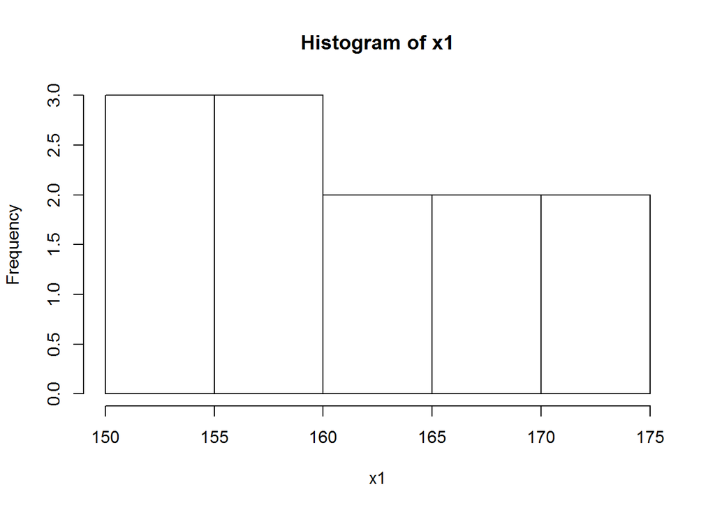

```r
hist(x1) #做出身高的直方图
```

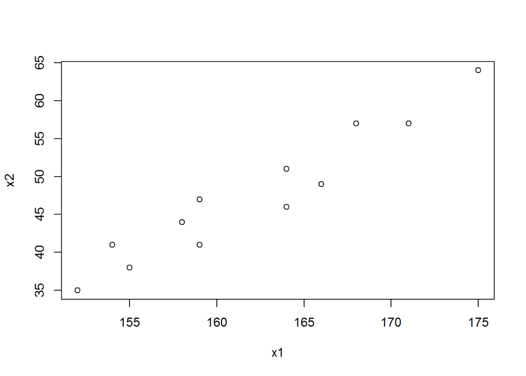

```r
plot(x1,x2) #做出身高和体重的散点图
```

```r
#下面的实验需要同学们先自己准备好数据文件
#(X=read.table("textdata.txt"))#读取名为textdata的txt格式文档
#(X=read.table("textdata.txt",header=T))#读取具有列标签的名为textdata的txt格式文档
#X=read.csv("textdata.csv")#读取名为textdata的csv格式文档
#library(RODBC)#加载RODBC软件包
#Rcode<-odbcConnectExcel("Rcode.xls")#读取名为Rcode的Excel工作薄
#(data<-sqlFetch(Rcode,"data"))#显示Rcode中名为data表单的数据
#(codedata <- sqlFetch(Rcode,"codedata"))#显示Rcode中名为codata表单的数据
```

```
数据框：可看成矩阵的推广，也可以看做是一种特殊的列表对象，list,
R语言特有的数据类型，数据框中的列表对象有如下限制：

1. 分量必须是向量(数值，字符，逻辑)，因子，数值矩阵，列表，或其他数据框；

2. 数值向量，逻辑值，因子保持原有的格式，而字符型向量会被转换成因子并且它的水平就是向量中出现的独立值；

3. 数据框中以变量形式出现的向量长度必须一致，举证结构必须有一样的行数。
```

## 多元数据的简单分析

1. 定量变量分析

1.`hist(x,freq=NULL,...)`

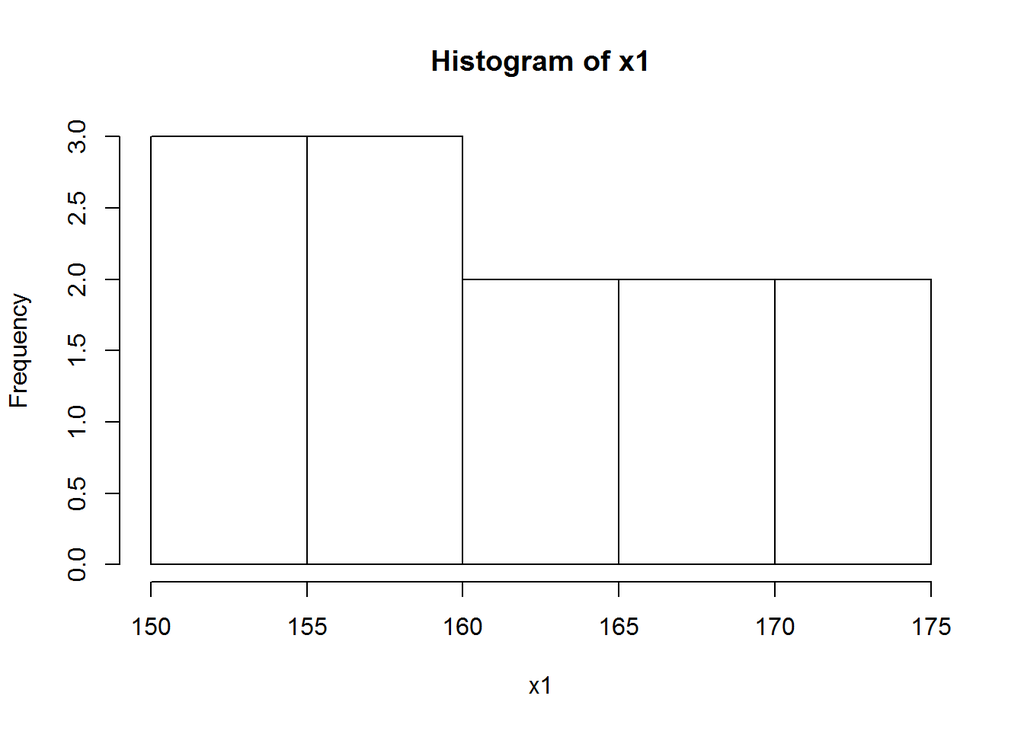

```r
 hist(x1)
```

2. 定量变量间的关系
- 散点图:`plot(x,y,...)`

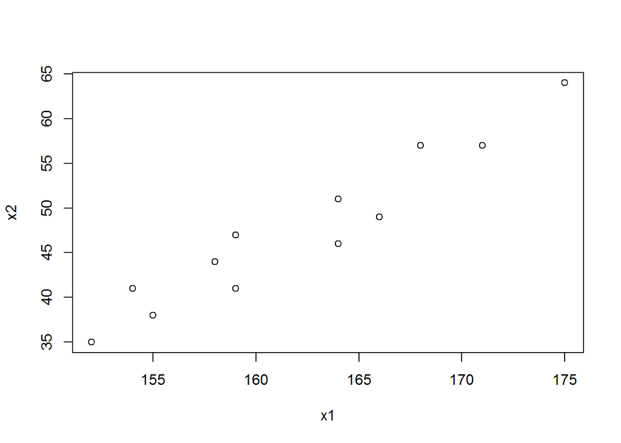

```
有没有强的线性关系，能否用来预测，是不是因果关系，如肺癌和吸烟，公鸡打鸣，需假设检验，来推断。
```

```r
  plot(x1,x2)
```

3. 定性变量分析
- 列联表：`table()`

```r
#从R凑得.xls中表单的data中选A1:G515，并复制到剪切板
#data=read.table("clipboard",header=T) #将剪切板数据读入数据框data中
#head(data)#显示前6组数据
#attach(data)#绑定数据
#table(年龄)#一维列联表
#barplot(table(年龄),col=1:7)#条形图
#pie(table(结果))#饼图
#table(年龄,性别) #二维列联表
#barplot(table(年龄,性别),beside=T,col=1:7)#以性别分组的年龄条图
#barplot(table(性别,年龄),beside=T,col=1:2)#以年龄分组的性别条图
#ftable(年龄,性别,结果) #以年龄、性别排列的结果频数三维列联表
#ftable(性别,年龄,结果)#以性别、年龄排列的结果频数三维列联表
#(ft=ftable(性别,结果,年龄))#显示以性别、结果排列的年龄频数三维列联表
#rowSums(ft)#求行和
#colSums(ft)#求列和
#sum(ft)#求总和
```

# 案例分析

每一列为一个变量的不同观测值，每一行为一个观测单位，它是由定量值和定性值组成的向量，每一个值对应于一个向量。

```r
rm(list=ls())#清理内存

options(digits = 4)#保留4为输出

par(mar=c(4,4,2,1)+0.1,cex=0.8)#图形修饰

#load('mvstats.RData')
##########【案例1】##########
#mvcase3.xls"的表单Case1中选择数据并复制
Case1=read.table("clipboard",header=T)
head(Case1)
```

```
##   地区 性别 教育程度   观点 年龄 月收入 月支出
## 1    A   女       中 不支持   55   2299   1423
## 2    A   女       低 不支持   39   3378   2022
## 3    A   女       中   支持   33   3460   1868
## 4    B   男       高   支持   41   4564   1918
## 5    B   女       高 不支持   55   3206   1906
## 6    A   女       中 不支持   48   4043   2233
```

```r
summary(Case1)
```

```
##  地区    性别     教育程度     观点          年龄          月收入
##  A:204   男:603   低:319   不支持:628   Min.   : 6.0   Min.   : 637
##  B:401   女:597   高:303   支持  :568   1st Qu.:34.0   1st Qu.:2388
##  C:384            中:578   NA's  :  4   Median :40.0   Median :2978
##  D:211                                  Mean   :40.1   Mean   :3006
##                                         3rd Qu.:47.0   3rd Qu.:3624
##                                         Max.   :72.0   Max.   :6239
##      月支出
##  Min.   : 797
##  1st Qu.:1722
##  Median :1993
##  Mean   :1997
##  3rd Qu.:2262
##  Max.   :3385
```

```r
attach(Case1)  #绑定数据
 T1=table(地区);T1
```

```
## 地区
##   A   B   C   D
## 204 401 384 211
```

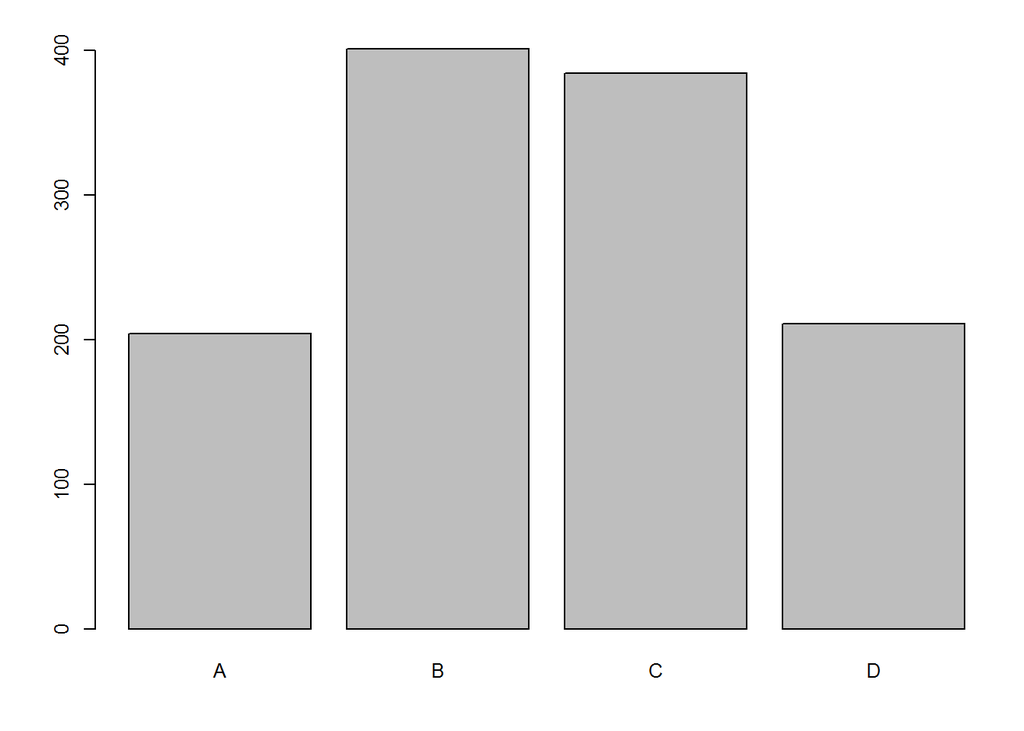

```r
 barplot(T1)
```

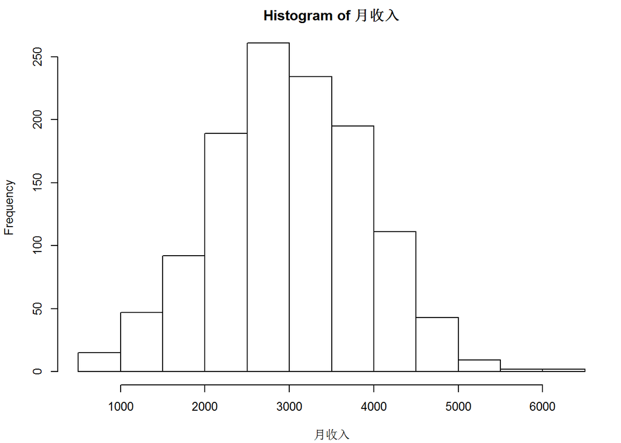

```
## $breaks
##  [1]  500 1000 1500 2000 2500 3000 3500 4000 4500 5000 5500 6000 6500
##
## $counts
##  [1]  15  47  92 189 261 234 195 111  43   9   2   2
##
## $density
##  [1] 2.500e-05 7.833e-05 1.533e-04 3.150e-04 4.350e-04 3.900e-04 3.250e-04
##  [8] 1.850e-04 7.167e-05 1.500e-05 3.333e-06 3.333e-06
##
## $mids
##  [1]  750 1250 1750 2250 2750 3250 3750 4250 4750 5250 5750 6250
##
## $xname
## [1] "月收入"
##
## $equidist
## [1] TRUE
##
## attr(,"class")
## [1] "histogram"
```

```r
 f=hist(月收入);f  #月收入直方图
```

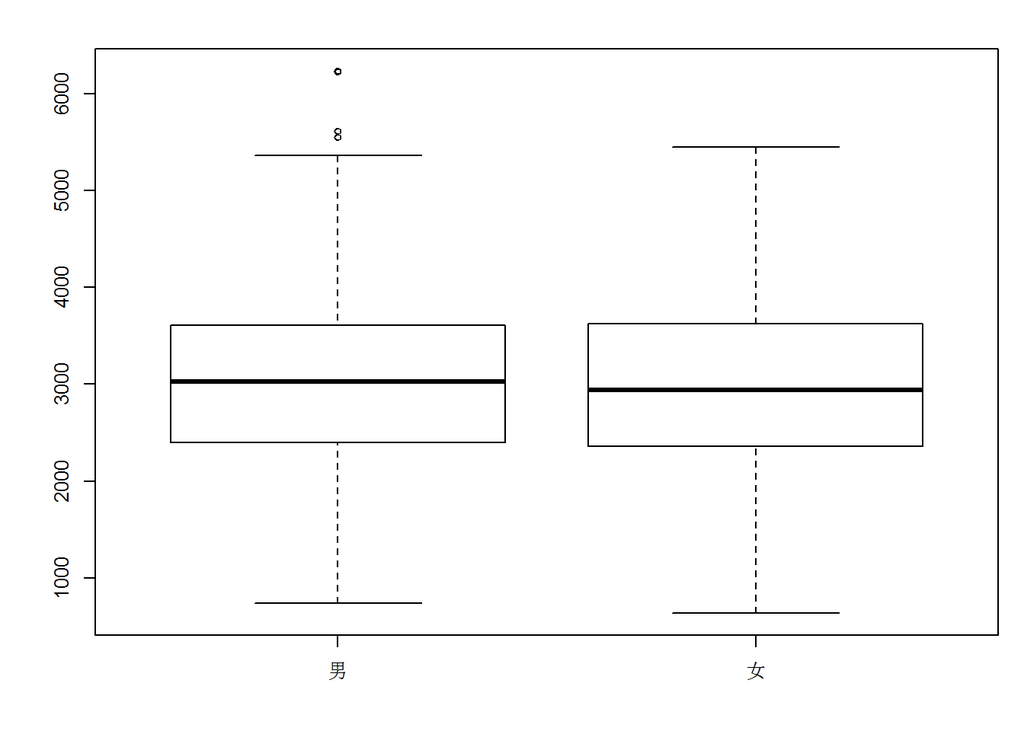

```r
 boxplot(月收入~性别)
```

```r
 t.test(月收入~性别)
```

```
##
##  Welch Two Sample t-test
##
## data:  月收入 by 性别
## t = 0.51, df = 1200, p-value = 0.6
## alternative hypothesis: true difference in means is not equal to 0
## 95 percent confidence interval:
##  -75.43 128.49
## sample estimates:
## mean in group 男 mean in group 女
##             3019             2993
```

```r
 T2=table(性别,观点);T2
```

```
##     观点
## 性别 不支持 支持
##   男    319  282
##   女    309  286
```

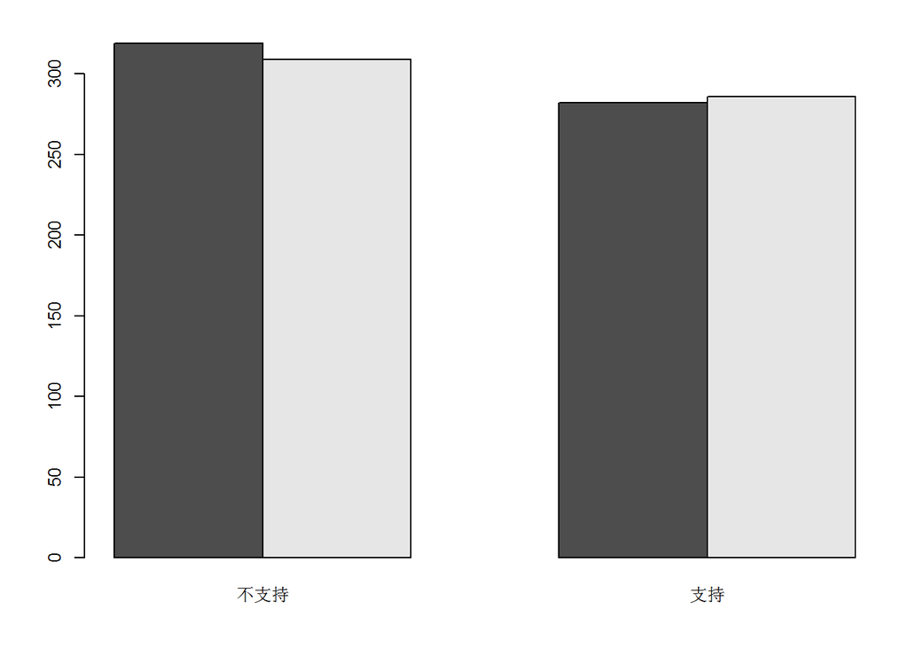

```r
 barplot(T2,beside=T)
```

```r
 T3=ftable(性别,教育程度,观点);T3
```

```
##               观点 不支持 支持
## 性别 教育程度
## 男   低                81   88
##      高                78   66
##      中               160  128
## 女   低                82   68
##      高                86   72
##      中               141  146
```

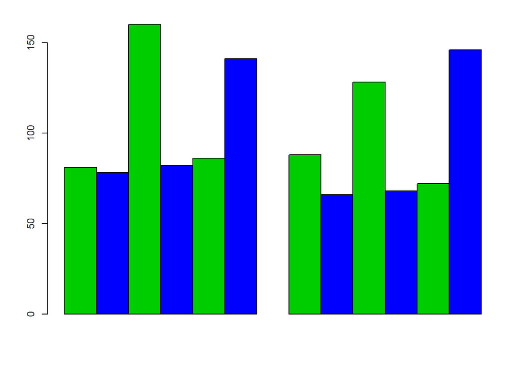

```r
 barplot(T3,beside=T,col=3:4)
```

```r
 T4=ftable(教育程度,性别,观点);T4
```

```
##               观点 不支持 支持
## 教育程度 性别
## 低       男            81   88
##          女            82   68
## 高       男            78   66
##          女            86   72
## 中       男           160  128
##          女           141  146
```

```r
detach(Case1) #解除绑定
```

`ftable(性别,教育程度,观点)` 以性别和教育程度排列的观点频数三维列联表

`ftable(教育程度,性别,观点)` 以教育程度和性别排列的观点频数三维列联表

无论何种形式的列联表，结果都一样。

观点变量：2水平，支持和不支持 性别变量：2水平，男和女 教育程度变量：3水平，低中高

总共是2* 2 *3=12种组合情况。

如有错误请联系 [e-mail]:shixiangbupt@qq.com.